# GeneGraphs: demo package

Betzabeth Imaicela, & Johanna Tanguila

2023-04-01

`GeneGraphs` es un package que permite la visualización de datos de expresión génica, contiene funciones que permiten realizar analisis exploratorio y estadistico.

```r
library(RTCGA);library(RTCGA); library(RTCGA.mRNA); library(ggplot2);
library(ggpubr); library(FactoMineR); library(factoextra); library(dplyr);
library(ggplot2); library(carData); library(car); library(multcomp);
library(reshape2); library(ggpubr);
```

```r
expr <- expressionsTCGA(BRCA.mRNA, OV.mRNA, LUSC.mRNA,
                        extract.cols = c("GATA3", "PTEN", "XBP1","ESR1", "MUC1"))
nb_samples <- table(expr$dataset)
expr$dataset <- gsub(pattern = ".mRNA", replacement = "",  expr$dataset)
expr$bcr_patient_barcode <- paste0(expr$dataset, c(1:590, 1:561, 1:154))
expr <- read.delim("https://raw.githubusercontent.com/kassambara/data/master/expr_tcga.txt",
                   stringsAsFactors = FALSE)
```

### Función 1: boxplot_expression

```r
boxplot_expression <- function(data, x_var, y_var) {
  library(ggpubr)
  if (!x_var %in% colnames(data)) {
    stop(paste("La variable especificada para el eje x (", x_var, ") no se encuentra en el conjunto de datos.", sep = ""))
  }
  if (y_var != "all" & !all(y_var %in% colnames(data))) {
    stop(paste("Una o más de las variables especificadas para el eje y (", paste(y_var, collapse = ", "), ") no se encuentran en el conjunto de datos.", sep = ""))
  }
  if (y_var == "all") {
    y_vars <- colnames(data)[!colnames(data) %in% c(x_var, "bcr_patient_barcode")]
  } else {
    y_vars <- y_var
  }
  ggboxplot(data, x = x_var,
            y = y_vars,
            merge = "flip",
            ylab = "Expression",
            xlab = "Dataset",
            color = x_var) +
    scale_fill_manual(values = c("#A9A9A9", "#808080", "#696969")) +
    theme_grey() +
    theme(legend.position = "top")
}
```

La función `boxplot_expression` toma como argumentos un conjunto de datos (`data`), una variable para el eje x (`x_var`) y una o más variables para el eje y (`y_var`). Esta función genera un gráfico de caja para visualizar la distribución de los valores de las variables del eje y para cada valor de la variable del eje x.

Si se especifica el valor `"all"` para el argumento `y_var`, la función incluirá todas las columnas del conjunto de datos que no sean la variable del eje x ni la columna `"bcr_patient_barcode"`.

La función verifica si las variables especificadas para los ejes x e y se encuentran en el conjunto de datos. Si alguna de las variables no se encuentra en el conjunto de datos, la función generará un error con un mensaje apropiado.

Ejemplo de uso:

Generar un gráfico de caja para un solo gen

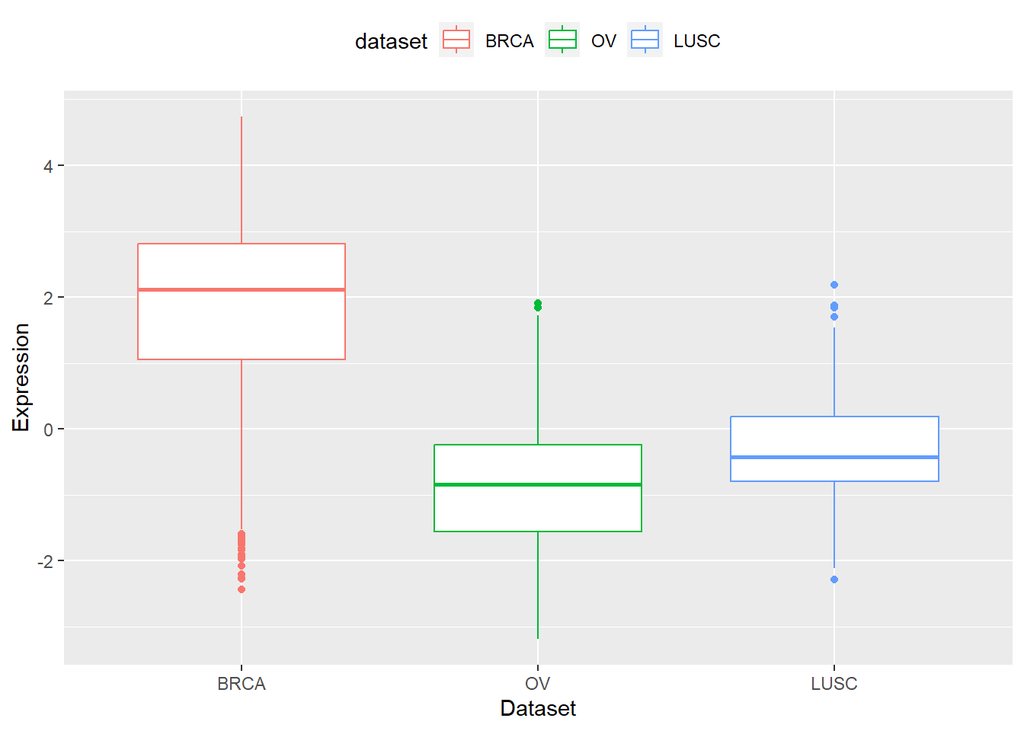

```r
boxplot_expression(expr, "dataset", "XBP1")
```

Generar un gráfico de caja para todos los genes disponibles en el conjunto de datos

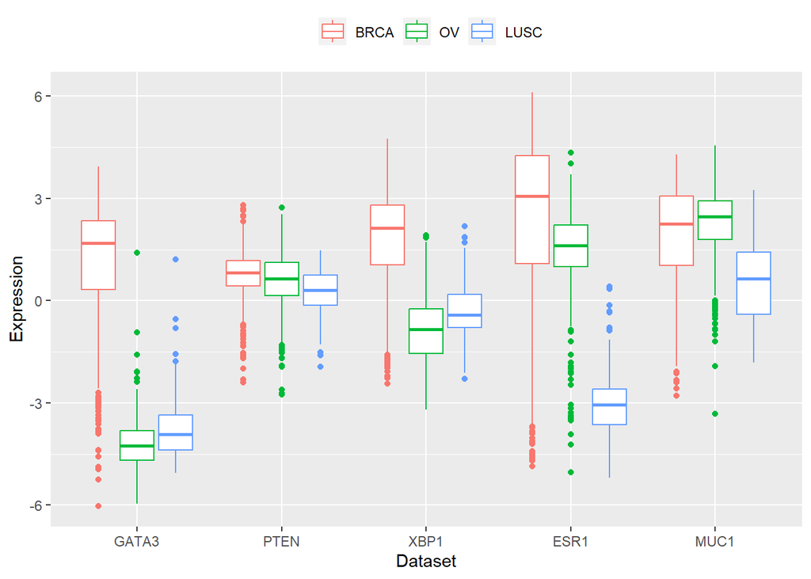

```r
boxplot_expression(expr, "dataset", "all")
```

### Función 3: `jiterplot_expression`

```r
jitterplot_expression <- function(data, x_var, y_vars) {
  library(ggpubr)
  library(reshape2)
  if (!x_var %in% colnames(data)) {
    stop(paste("La variable especificada para el eje x (", x_var, ") no se encuentra en el conjunto de datos.", sep = ""))
  }
  if (y_vars != "all" & !all(y_vars %in% colnames(data))) {
    stop(paste("Una o más de las variables especificadas para el eje y (", paste(y_vars, collapse = ", "), ") no se encuentran en el conjunto de datos.", sep = ""))
  }
  if (y_vars == "all") {
    y_vars <- colnames(data)[!colnames(data) %in% c(x_var, "bcr_patient_barcode")]
  }
  data_long <- reshape2::melt(data, id.vars = x_var, measure.vars = y_vars)
  ggplot(data_long, aes_string(x = x_var, y = "value", color = x_var)) +
    geom_boxplot() +
    geom_jitter(width = 0.2, size = 0.1) +
    scale_fill_manual(values = c("#00AFBB", "#E7B800", "#FC4E07")) +
    labs(x = "Cohort type", y = "Expresión", color = "Cohort") +
    theme(legend.position = "bottom") +
    stat_compare_means(comparisons = list(c("BRCA", "OV"), c("OV", "LUSC"))) +
    theme_grey() +
    facet_wrap(~ variable)
}
```

La función `jitterplot_expression` toma como argumentos un conjunto de datos (`data`), una variable para el eje x (`x_var`) y una o más variables para el eje y (`y_vars`). Esta función genera un gráfico de caja con puntos jitter para visualizar la distribución de los valores de las variables del eje y para cada valor de la variable del eje x. El gráfico incluye facetas para cada variable del eje y.

Igual que la anterior función si se especifica el valor `"all"` para el argumento `y_vars`, la función incluirá todas las columnas del conjunto de datos que no sean la variable del eje x ni la columna `"bcr_patient_barcode"`.

La función verifica si las variables especificadas para los ejes x e y se encuentran en el conjunto de datos. Si alguna de las variables no se encuentra en el conjunto de datos, la función generará un error con un mensaje apropiado.

Ejemplo de uso:

Generar un gráfico de caja con puntos jitter para un solo gen

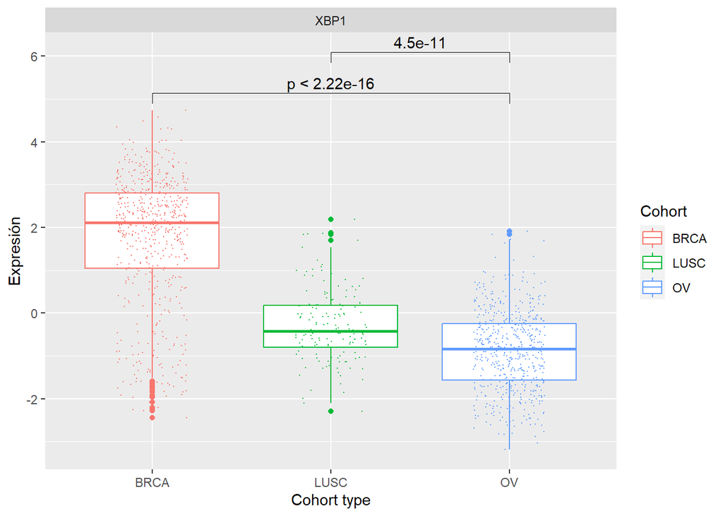

```r
jitterplot_expression(expr, "dataset", "XBP1")
```

Generar un gráfico de caja con puntos jitter para todos los genes disponibles en el conjunto de datos

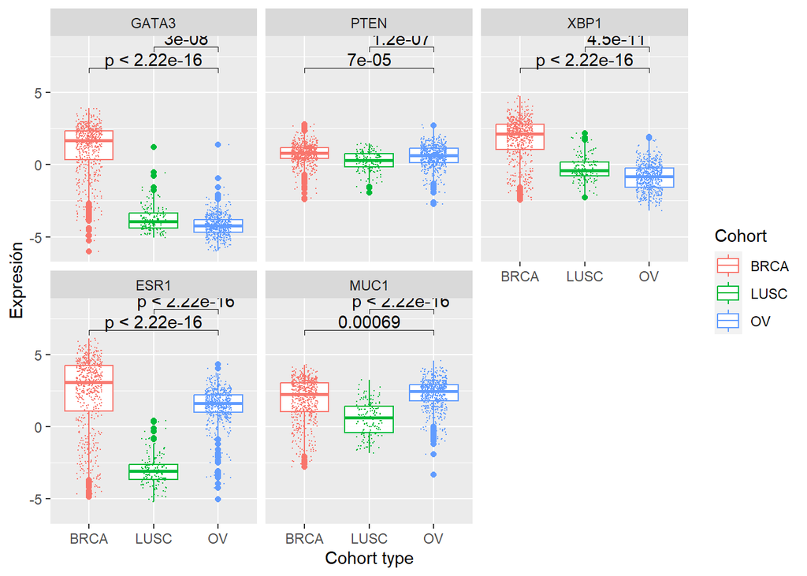

```r
jitterplot_expression(expr, "dataset", "all")
```

### Función 3: `plotdensity_cancer`

```r
plotdensity_cancer <- function(data, dataset_col, cancer_type) {
  library(ggplot2)
  library(reshape2)

  if (!dataset_col %in% colnames(data)) {
    stop(paste("La variable especificada para el conjunto de datos (", dataset_col, ") no se encuentra en el conjunto de datos.", sep = ""))
  }

  if (cancer_type != "all" & !cancer_type %in% unique(data[[dataset_col]])) {
    stop(paste("El tipo de cáncer especificado (", cancer_type, ") no se encuentra en el conjunto de datos.", sep = ""))
  }

  if (cancer_type != "all") {
    data <- subset(data, data[[dataset_col]] == cancer_type)
  }

  # Convertir los datos a formato largo
  expr_long <- melt(data, id.vars = dataset_col, measure.vars = c("GATA3", "PTEN", "XBP1", "MUC1", "ESR1"))

  ggplot(expr_long, aes(x = value, color = variable, fill = variable)) +
    geom_density(alpha = 0.5) +
    geom_rug() +
    geom_vline(aes(xintercept = median(value)), linetype = "dashed") +
    scale_fill_manual(values = c("#00AFBB", "#E7B800", "#FC4E07", "#C0C0C0", "#FFD700"))+
    scale_fill_manual(values = c("#00AFBB", "#E7B800", "#FC4E07", "#C0C0C0", "#FFD700")) +
    labs(x = "Expression", y = "Count", color = "Gene", fill = "Gene") +
    theme_grey()+
    facet_wrap(as.formula(paste("~", dataset_col)))
}
```

La función `plotdensity_cancer` toma como argumentos un conjunto de datos (`data`), el nombre de la columna que contiene el tipo de cáncer (`dataset_col`) y el tipo de cáncer para el cual se desea generar el gráfico (`cancer_type`). Esta función genera un gráfico de densidad para visualizar la distribución de los valores de expresión génica para un tipo de cáncer específico o para todos los tipos de cáncer disponibles en el conjunto de datos.

Si se especifica el valor `"all"` para el argumento `cancer_type`, la función incluirá todos los tipos de cáncer disponibles en el conjunto de datos.

La función verifica si la columna especificada para el tipo de cáncer se encuentra en el conjunto de datos y si el tipo de cáncer especificado se encuentra en los valores únicos de esa columna. Si alguna de estas condiciones no se cumple, la función generará un error con un mensaje apropiado.

Ejemplo de uso:

Generar un gráfico de densidad para un solo tipo de cáncer

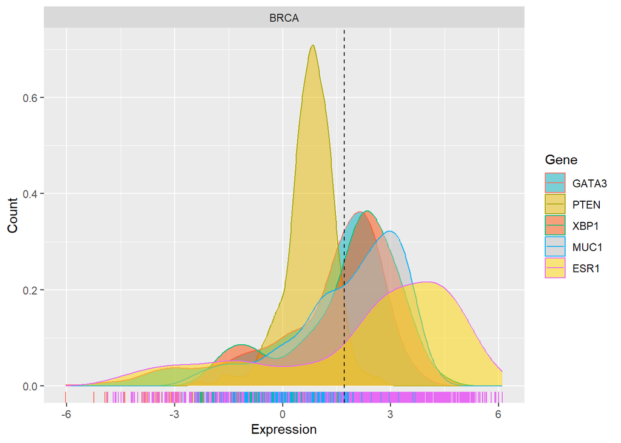

```r
plotdensity_cancer(expr, "dataset", "BRCA")
```

Generar un gráfico de densidad para todos los tipos de cáncer disponibles en el conjunto de datos

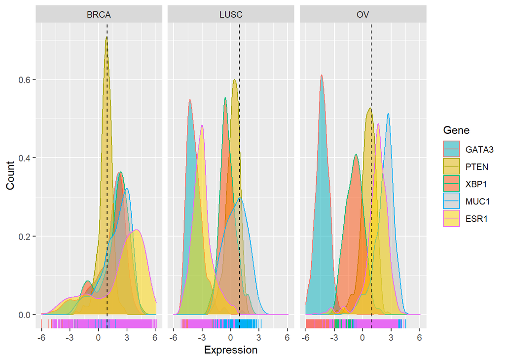

```r
plotdensity_cancer(expr, "dataset", "all")
```

### Función 4: `plot_pca`

```r
plot_pca <- function(data) {
  library(FactoMineR)
  library(factoextra)
  library(dplyr)

  # Seleccionamos solo las variables cuantitativas
  expr_num <- select_if(data, is.numeric)

  if (ncol(expr_num) == 0) {
    stop("Error: Los datos no contienen ninguna variable cuantitativa.")
  }

  # Realizamos el análisis de componentes principales
  res.pca <- PCA(expr_num, graph = FALSE)

  # Grafico de individuos
  fviz_pca_ind(res.pca, geom.ind = "point", pointshape = 21,
               pointsize = 2,
               fill.ind = data$dataset,
               col.ind = "black",
               palette = "jco",
               addEllipses = TRUE,
               label = "var",
               col.var = "black",
               repel = TRUE,
               legend.title = "Cohort") +
    ggtitle("2D PCA-plot from expr cohort") +
    theme(plot.title = element_text(hjust = 0.5))+
    theme_grey()
}
```

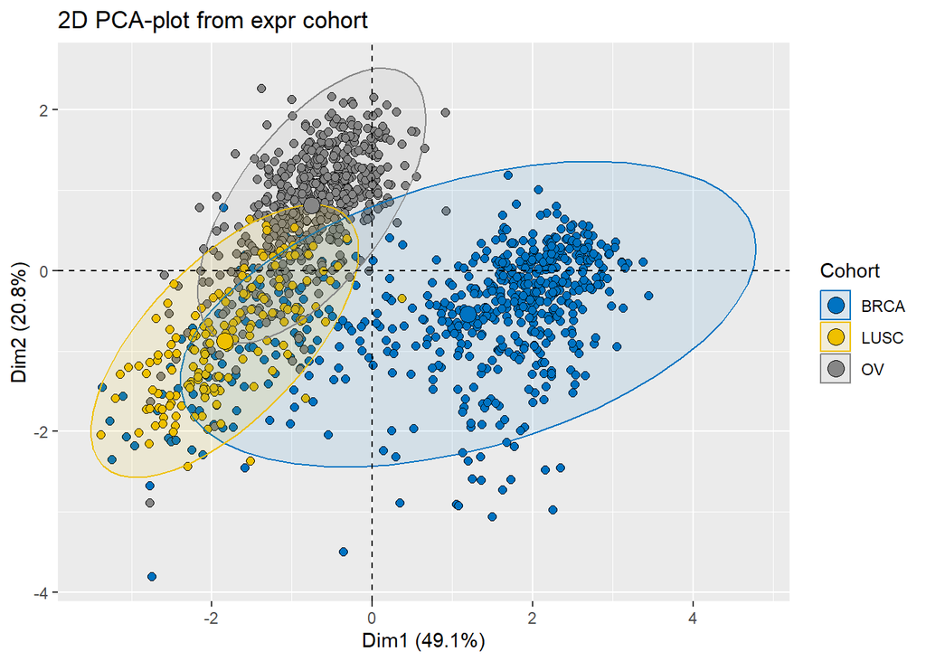

```r
plot_pca(expr)
```

### Función 5: `anova_tukey_tests`

```r
anova_tukey_tests <- function(data, analysis_choice) {
  # Cargamos los paquetes necesarios
  library(carData)
  library(car)
  library(multcomp)

  if (analysis_choice == 1) {
    # ANOVA
    # Realizamos la prueba ANOVA para cada gen
    for (gen in colnames(data)[-c(1,2)]) {
      formula <- as.formula(paste(gen, "~ dataset"))
      anova_result <- Anova(aov(formula, data = data))
      print(anova_result)
    }
  } else if (analysis_choice == 2) {
    # Prueba Tukey
    data$dataset <- factor(data$dataset)

    # Realizamos la prueba de Tukey para cada gen
    for (gen in colnames(data)[-c(1,2)]) {
      formula <- as.formula(paste(gen, "~ dataset"))
      tukey_result <- glht(aov(formula, data = data), linfct = mcp(dataset = "Tukey"))
      print(summary(tukey_result))
    }
  } else {
    stop("Error: Opción no válida. Ingrese 1 para realizar el Test ANOVA o 2 para el Test Tukey.")
  }
}
```

La función `anova_tukey_tests` permite realizar pruebas ANOVA y Tukey en los datos. Esta función toma un conjunto de datos como argumento y te permite especificar qué análisis deseas realizar.

Ejemplo de uso: Realizar el Test ANOVA

```r
anova_tukey_tests(expr, 1)
```

```
## Anova Table (Type II tests)
##
## Response: GATA3
##           Sum Sq   Df F value    Pr(>F)
## dataset   8862.9    2  2467.6 < 2.2e-16 ***
## Residuals 2338.2 1302
## ---
## Signif. codes:  0 '***' 0.001 '**' 0.01 '*' 0.05 '.' 0.1 ' ' 1
## Anova Table (Type II tests)
##
## Response: PTEN
##           Sum Sq   Df F value   Pr(>F)
## dataset    31.87    2  30.374 1.28e-13 ***
## Residuals 683.05 1302
## ---
## Signif. codes:  0 '***' 0.001 '**' 0.01 '*' 0.05 '.' 0.1 ' ' 1
## Anova Table (Type II tests)
##
## Response: XBP1
##           Sum Sq   Df F value    Pr(>F)
## dataset   2056.9    2  698.19 < 2.2e-16 ***
## Residuals 1917.9 1302
## ---
## Signif. codes:  0 '***' 0.001 '**' 0.01 '*' 0.05 '.' 0.1 ' ' 1
## Anova Table (Type II tests)
##
## Response: ESR1
##           Sum Sq   Df F value    Pr(>F)
## dataset   3443.8    2  445.97 < 2.2e-16 ***
## Residuals 5027.0 1302
## ---
## Signif. codes:  0 '***' 0.001 '**' 0.01 '*' 0.05 '.' 0.1 ' ' 1
## Anova Table (Type II tests)
##
## Response: MUC1
##            Sum Sq   Df F value    Pr(>F)
## dataset    352.04    2  108.08 < 2.2e-16 ***
## Residuals 2120.50 1302
## ---
## Signif. codes:  0 '***' 0.001 '**' 0.01 '*' 0.05 '.' 0.1 ' ' 1
```

```r
anova_tukey_tests(expr, 2)
```

```
##
##   Simultaneous Tests for General Linear Hypotheses
##
## Multiple Comparisons of Means: Tukey Contrasts
##
##
## Fit: aov(formula = formula, data = data)
##
## Linear Hypotheses:
##                  Estimate Std. Error t value Pr(>|t|)
## LUSC - BRCA == 0 -4.86190    0.12126 -40.093   <0.001 ***
## OV - BRCA == 0   -5.32900    0.07902 -67.435   <0.001 ***
## OV - LUSC == 0   -0.46710    0.12191  -3.831   <0.001 ***
## ---
## Signif. codes:  0 '***' 0.001 '**' 0.01 '*' 0.05 '.' 0.1 ' ' 1
## (Adjusted p values reported -- single-step method)
##
##
##   Simultaneous Tests for General Linear Hypotheses
##
## Multiple Comparisons of Means: Tukey Contrasts
##
##
## Fit: aov(formula = formula, data = data)
##
## Linear Hypotheses:
##                  Estimate Std. Error t value Pr(>|t|)
## LUSC - BRCA == 0 -0.49692    0.06554  -7.582  < 1e-05 ***
## OV - BRCA == 0   -0.17606    0.04271  -4.122 9.58e-05 ***
## OV - LUSC == 0    0.32085    0.06589   4.869  < 1e-05 ***
## ---
## Signif. codes:  0 '***' 0.001 '**' 0.01 '*' 0.05 '.' 0.1 ' ' 1
## (Adjusted p values reported -- single-step method)
##
##
##   Simultaneous Tests for General Linear Hypotheses
##
## Multiple Comparisons of Means: Tukey Contrasts
##
##
```

[output cut: 29 more lines]

```
##   Simultaneous Tests for General Linear Hypotheses
##
## Multiple Comparisons of Means: Tukey Contrasts
##
##
## Fit: aov(formula = formula, data = data)
##
## Linear Hypotheses:
##                  Estimate Std. Error t value Pr(>|t|)
## LUSC - BRCA == 0 -1.29050    0.11548  -11.18  < 1e-08 ***
## OV - BRCA == 0    0.41463    0.07526    5.51 8.84e-08 ***
## OV - LUSC == 0    1.70514    0.11610   14.69  < 1e-08 ***
## ---
## Signif. codes:  0 '***' 0.001 '**' 0.01 '*' 0.05 '.' 0.1 ' ' 1
## (Adjusted p values reported -- single-step method)
```